# Animating Tracking Data

For the following vignette, you’ll need the `sportyR`, `ggplot2`, and `gganimate` packages loaded into your workspace.

```r
library(sportyR)
library(ggplot2)
library(gganimate)
```

If this is your first experience with plotting tracking data, please check out the plotting-tracking-data vignette. Otherwise, let’s see how to make GIFs with `sportyR` and `gganimate`.

## The Data

For this example, we’ll use a play from Week 15 of the 2018 NFL season between the Chicago Bears and Green Bay Packers. Data made available for the [Big Data Bowl 2021](https://www.kaggle.com/c/nfl-big-data-bowl-2021) Kaggle competition.

```r
# Load the play data
example_nfl_play <- data.table::fread(
  glue::glue(
    "https://raw.githubusercontent.com/sportsdataverse/sportyR/",
    "main/data-raw/example-pbp-data.csv"
  )
)

# Convert to data frame
example_nfl_play <- as.data.frame(example_nfl_play)
```

To keep things easy, let’s specify the colors for each team’s dots on the resulting GIF. We’ll make the Bears orange and the Packers yellow. The football will also need a dot to be seen; let’s make it brown.

```r
# Prep data for plotting
example_nfl_play[example_nfl_play["team"] == "home", "color"] <- "#c83803"
example_nfl_play[example_nfl_play["team"] == "away", "color"] <- "#ffb612"
example_nfl_play[example_nfl_play["team"] == "football", "color"] <- "#624a2e"
```

First, let’s draw an NFL field via `geom_football("nfl")`. We’ll adjust the origin to be in the lower left corner of the field, as per the notes on the coordinate system on the Kaggle page describing the data.

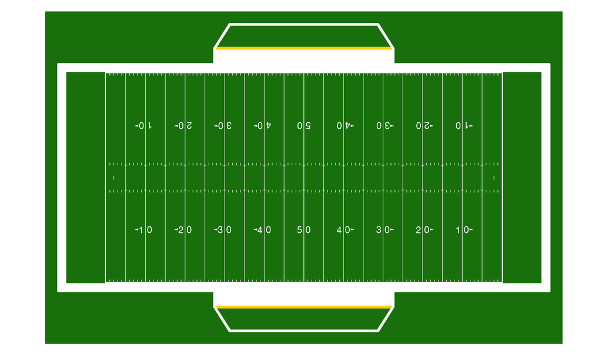

Image of NFL field rendered from sportyR

```r
# Create the field
nfl_field <- geom_football("nfl", x_trans = 60, y_trans = 26.6667)

# Display the field
nfl_field
```

Looks good! Now, let’s animate using `gganimate`.

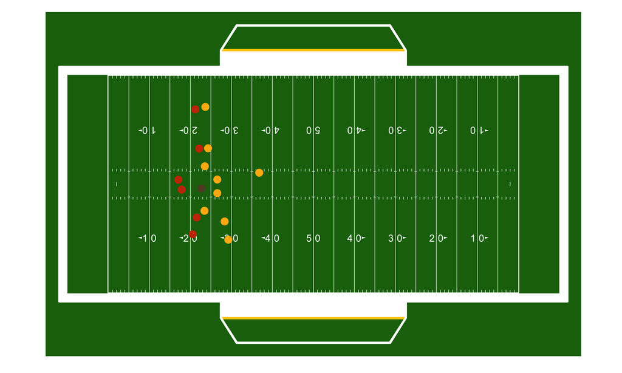

Gif of tracking data

```r
# Add the points on the field
play_anim <- nfl_field +
  geom_point(
    data = example_nfl_play,
    aes(x, y),
    color = example_nfl_play$color
  ) +
  transition_time(example_nfl_play$frameId)

# Show the animation
play_anim
```

Easy peasy. As noted on the plotting-tracking-data vignette, this too works so long as the geospatial data is provided and contains a way to identify and order the frames of the resulting GIF.